# hw-03

Your Name (S2960448)

2026-11-20

## Data load and preparation before modelling

```r
gss16<-read.csv("data/gss16.csv")
```

#### Cleaning and selecting columns

```r
gss16_advfront <- gss16 %>%
  select(advfront, emailhr, educ, polviews, wrkstat) %>%
  drop_na()
```

#### Re-levelling `advfront`

```r
gss16_advfront <- gss16_advfront %>%
  mutate(
    advfront = case_when(
      advfront == "Strongly agree" ~ "Agree",
      advfront == "Agree" ~ "Agree",
      TRUE ~ "Not agree"
    ),
    advfront = fct_relevel(advfront, "Not agree", "Agree")
  )
```

#### Re-levelling `polviews`

```r
gss16_advfront <- gss16_advfront %>%
  mutate(
    polviews = case_when(
      str_detect(polviews, "[Cc]onservative") ~ "Conservative",
      str_detect(polviews, "[Ll]iberal") ~ "Liberal",
      TRUE ~ polviews
    ),
    polviews = fct_relevel(polviews, "Conservative", "Moderate", "Liberal")
  )
```

## Exercise 1: Create a linear regression model

#### Exercise 1 (a)

```r
lm_spec <- linear_reg() %>%
  set_engine("lm") %>%
  set_mode("regression")

fit_ex1 <- lm_spec %>%
  fit(emailhr ~ educ, data = gss16_advfront)


fit_ex1 %>% tidy()
```

```
## # A tibble: 2 × 5
##   term        estimate std.error statistic       p.value
##   <chr>          <dbl>     <dbl>     <dbl>         <dbl>
## 1 (Intercept)   -2.76      1.66      -1.66 0.0970
## 2 educ           0.685     0.116      5.92 0.00000000413
```

```r
fit_ex1 %>% glance()
```

```
## # A tibble: 1 × 12
##   r.squared adj.r.squared sigma statistic       p.value    df logLik   AIC   BIC
##       <dbl>         <dbl> <dbl>     <dbl>         <dbl> <dbl>  <dbl> <dbl> <dbl>
## 1    0.0291        0.0283  10.9      35.1 0.00000000413     1 -4458. 8922. 8937.
## # ℹ 3 more variables: deviance <dbl>, df.residual <int>, nobs <int>
```

emailhr = -2.7573 + 0.6855 *educ. One additional year of education is associated with an average increase of 0.6855 hours per week spent on email.The R^2 value is 0.0291, meaning years of education explains approximately 2.91% of the variation in weekly email hours. The overall F-test is statistically significant (p < 0.001), yet the low R^2 shows `educ` is a weak predictor of `emailhr`.

#### Exercise 1 (b)

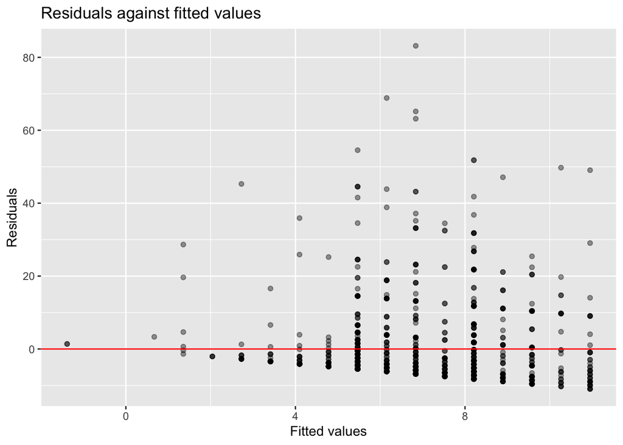

```r
library(ggplot2)
library(broom)

aug_ex1 <- augment(fit_ex1, new_data = gss16_advfront) %>%
  mutate(resid = emailhr - .pred)

# Residual vs fitted (.pred) plot
ggplot(aug_ex1, aes(x = .pred, y = resid)) +
  geom_point(alpha = 0.4) +
  geom_hline(yintercept = 0, colour = "red") +
  labs(x = "Fitted values", y = "Residuals",
       title = "Residuals against fitted values")
```

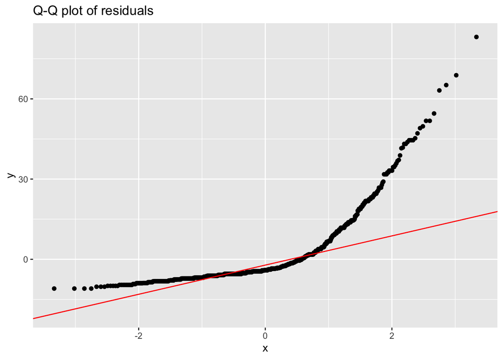

```r
# QQ plot for residuals
ggplot(aug_ex1, aes(sample = resid)) +
  geom_qq() +
  geom_qq_line(colour = "red") +
  labs(title = "Q-Q plot of residuals")
```

Linearity: No obvious curve, linearity assumption holds. Homoscedasticity: Residual variance increases with fitted values → heteroscedastic, assumption violated. Normality: QQ plot deviates from the line at both tails; residuals are not normally distributed. Conclusion: The model violates homoscedasticity and normality assumptions. Interpret hypothesis tests carefully.

## Exercise 2: Compare two linear models

#### Exercise 2 (a)

```r
multi_spec <- linear_reg() %>%
  set_engine("lm") %>%
  set_mode("regression")

multi_fit <- fit(multi_spec, emailhr ~ educ + polviews, data = gss16_advfront)
multi_fit %>% tidy()
```

```
## # A tibble: 4 × 5
##   term             estimate std.error statistic       p.value
##   <chr>               <dbl>     <dbl>     <dbl>         <dbl>
## 1 (Intercept)        -3.10      1.74     -1.78  0.0756
## 2 educ                0.704     0.118     5.99  0.00000000285
## 3 polviewsModerate    0.433     0.758     0.571 0.568
## 4 polviewsLiberal    -0.284     0.813    -0.349 0.727
```

```r
multi_fit %>% glance()
```

```
## # A tibble: 1 × 12
##   r.squared adj.r.squared sigma statistic     p.value    df logLik   AIC   BIC
##       <dbl>         <dbl> <dbl>     <dbl>       <dbl> <dbl>  <dbl> <dbl> <dbl>
## 1    0.0298        0.0273  10.9      12.0 0.000000101     3 -4457. 8925. 8950.
## # ℹ 3 more variables: deviance <dbl>, df.residual <int>, nobs <int>
```

The multiple regression of `emailhr` on `educ` and categorical `polviews` (reference = Conservative) yields: emailhr=-3.1036 + 0.7041educ + 0.4329Moderate -0.2842Liberal.

```r
mod_reduced <- lm(emailhr ~ educ, data = gss16_advfront)
mod_full <- lm(emailhr ~ educ + polviews, data = gss16_advfront)
anova(mod_reduced, mod_full)
```

```
## Analysis of Variance Table
##
## Model 1: emailhr ~ educ
## Model 2: emailhr ~ educ + polviews
##   Res.Df    RSS Df Sum of Sq      F Pr(>F)
## 1   1170 138100
## 2   1168 138000  2       100 0.4232  0.655
```

We carry out a partial F-test to assess whether the categorical variable `polviews` contributes additional explanatory power to the model that already contains `educ`.

- Reduced model: `emailhr ~ educ`
- Full model: `emailhr ~ educ + polviews`

Hypotheses: H0: The coefficients for Moderate and Liberal are both equal to zero. After controlling for education, political views have no association with weekly email hours. H1: At least one coefficient for political views is non-zero.

From the ANOVA output, F = 0.4232, numerator df = 2, p = 0.655. Since the p-value is greater than 0.05, we fail to reject the null hypothesis.

Conclusion: `polviews` is not jointly statistically significant conditional on education. Adding political views does not significantly improve model fit. This finding is consistent with the individual non-significant t-tests for the two dummy variables of `polviews` in part 2a.

## Exercise 3: Create a workflow to fit a model

```r
set.seed(1234)
gss16_split <- initial_split(gss16_advfront)
gss16_train <- training(gss16_split)
gss16_test  <- testing(gss16_split)
```

#### Exercise 3 (a)

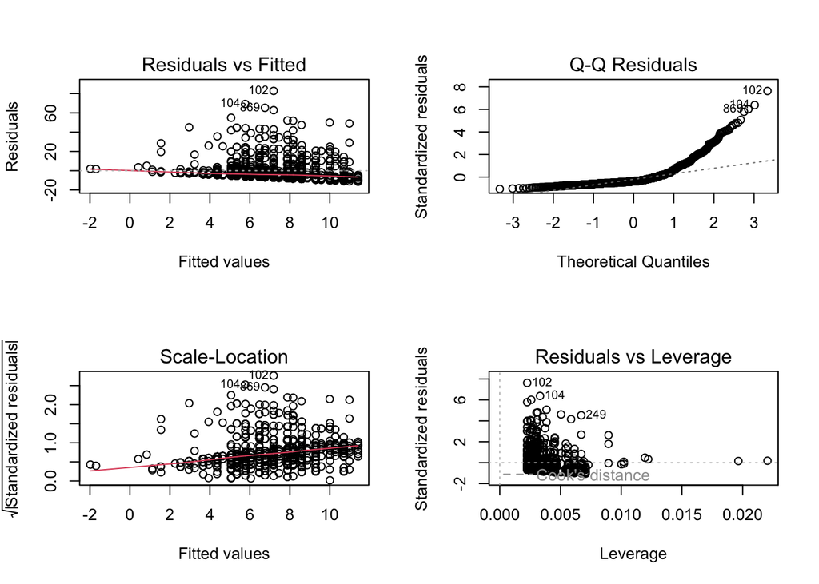

```r
mod_full <- lm(emailhr ~ educ + polviews, data = gss16_advfront)
par(mfrow=c(2,2))
plot(mod_full)
```

We assess the OLS assumptions for the regression model emailhr~educ + polviews using four residual diagnostic plots:

1. Residuals vs Fitted plot: Residuals spread wider as fitted values increase, showing a funnel shape. This indicates heteroscedasticity. No obvious curved pattern is observed, so the linearity assumption is roughly reasonable.
2. Normal Q-Q plot: The points deviate substantially from the reference line in the upper tail. The residuals are right‑skewed, so the normality assumption is violated.
3. Scale-Location plot: The smoothed red line slopes upward. The variability of standardised residuals rises with fitted values, confirming heteroscedasticity.
4. Residuals vs Leverage plot: Several observations (e.g. 102, 104) have large standardised residuals and are outliers. However, they do not cross the Cook’s distance contours, meaning they are not highly influential points.

Conclusion: The model fails the normality and homoscedasticity assumptions. The linearity assumption holds approximately, and there are no severe influential observations.

#### Exercise 3 (b)

```r
library(sandwich)
library(lmtest)
mod_full <- lm(emailhr ~ educ + polviews, data = gss16_advfront)
robust_se <- vcovHC(mod_full, type = "HC3")
coeftest(mod_full, vcov = robust_se)
```

```
##
## t test of coefficients:
##
##                  Estimate Std. Error t value  Pr(>|t|)
## (Intercept)      -3.10361    1.53637 -2.0201    0.0436 *
## educ              0.70410    0.11012  6.3938 2.334e-10 ***
## polviewsModerate  0.43291    0.76200  0.5681    0.5701
## polviewsLiberal  -0.28416    0.82103 -0.3461    0.7293
## ---
## Signif. codes:  0 '***' 0.001 '**' 0.01 '*' 0.05 '.' 0.1 ' ' 1
```

This table shows coefficient t-tests using HC3 robust standard errors to account for heteroscedasticity.

- The intercept is -3.1036 and statistically significant (p=0.0436).
- `educ` has a coefficient of 0.7041 and is highly significant (p<0.001). Holding political views constant, one additional year of education is associated with an average increase of 0.704 hours of weekly email time.
- `polviewsModerate` (beta=0.4329, p=0.5701) and `polviewsLiberal` (beta=-0.2842,p=0.7293) are both statistically insignificant at the 5% level. There is no significant difference in weekly email hours between moderate/liberal respondents and the conservative reference group.

Conclusion: After robust correction, education remains a significant positive predictor. Political views show no significant association with email hours, consistent with the partial F-test result from 2b.

#### Exercise 4 (a)

```r
mod_interact <- lm(emailhr ~ educ + polviews + educ:polviews, data = gss16_advfront)
summary(mod_interact)
```

```
##
## Call:
## lm(formula = emailhr ~ educ + polviews + educ:polviews, data = gss16_advfront)
##
## Residuals:
##     Min      1Q  Median      3Q     Max
## -11.479  -5.980  -4.123   1.675  82.868
##
## Coefficients:
##                       Estimate Std. Error t value Pr(>|t|)
## (Intercept)           -4.29210    2.91885  -1.470 0.141703
## educ                   0.78858    0.20369   3.871 0.000114 ***
## polviewsModerate       3.36251    4.03032   0.834 0.404282
## polviewsLiberal        0.18976    4.26509   0.044 0.964521
## educ:polviewsModerate -0.21275    0.28632  -0.743 0.457602
## educ:polviewsLiberal  -0.03609    0.29021  -0.124 0.901055
## ---
## Signif. codes:  0 '***' 0.001 '**' 0.01 '*' 0.05 '.' 0.1 ' ' 1
##
## Residual standard error: 10.88 on 1166 degrees of freedom
## Multiple R-squared:  0.03035,    Adjusted R-squared:  0.02619
## F-statistic: 7.299 on 5 and 1166 DF,  p-value: 9.581e-07
```

```r
library(sandwich)
library(lmtest)
robust_interact_vcov <- vcovHC(mod_interact, type = "HC3")
coeftest(mod_interact, vcov = robust_interact_vcov)
```

```
##
## t test of coefficients:
##
##                       Estimate Std. Error t value  Pr(>|t|)
## (Intercept)           -4.29211    2.71157 -1.5829 0.1137185
## educ                   0.78858    0.20270  3.8903 0.0001058 ***
## polviewsModerate       3.36251    3.81853  0.8806 0.3787288
## polviewsLiberal        0.18976    3.71408  0.0511 0.9592615
## educ:polviewsModerate -0.21275    0.28144 -0.7559 0.4498371
## educ:polviewsLiberal  -0.03609    0.26579 -0.1358 0.8920183
## ---
## Signif. codes:  0 '***' 0.001 '**' 0.01 '*' 0.05 '.' 0.1 ' ' 1
```

```r
mod_full <- lm(emailhr ~ educ + polviews, data = gss16_advfront)
anova(mod_full, mod_interact)
```

```
## Analysis of Variance Table
##
## Model 1: emailhr ~ educ + polviews
## Model 2: emailhr ~ educ + polviews + educ:polviews
##   Res.Df    RSS Df Sum of Sq      F Pr(>F)
## 1   1168 138000
## 2   1166 137925  2    74.896 0.3166 0.7287
```

We estimate a regression model including interaction terms between `educ` and `polviews` to test whether the association between education and weekly email hours differs by political views, with conservative respondents as the reference group.

- The coefficient on `educ` is 0.7886 and highly significant (p<0.001). For conservative respondents, one additional year of education is associated with an average increase of 0.7886 hours of weekly email time.
- The main terms for moderate and liberal political views are statistically insignificant.
- The two interaction terms `educ:polviewsModerate` (beta=-0.2128,p=0.4498) and `educ:polviewsLiberal` (beta=-0.0361,p=0.8920) are individually insignificant.
- The partial F-test for joint significance of the two interaction terms yields F=0.3166,p=0.7287>0.05.

Conclusion: We fail to find evidence that the effect of education on email hours varies across political groups. Adding these interaction terms does not improve the model.

#### Exercise 4 (b)

```r
mod_full <- lm(emailhr ~ educ + polviews, data = gss16_advfront)
mod_interact <- lm(emailhr ~ educ + polviews + educ:polviews, data = gss16_advfront)

anova(mod_full, mod_interact)
```

```
## Analysis of Variance Table
##
## Model 1: emailhr ~ educ + polviews
## Model 2: emailhr ~ educ + polviews + educ:polviews
##   Res.Df    RSS Df Sum of Sq      F Pr(>F)
## 1   1168 138000
## 2   1166 137925  2    74.896 0.3166 0.7287
```

```r
AIC(mod_full, mod_interact)
```

```
##              df      AIC
## mod_full      5 8924.724
## mod_interact  7 8928.088
```

```r
BIC(mod_full, mod_interact)
```

```
##              df      BIC
## mod_full      5 8950.056
## mod_interact  7 8963.553
```

We compare the main-effect model and the interaction model using the partial F-test, AIC and BIC. The partial F-test for joint significance of the two interaction terms gives F=0.3166,p=0.7287>0.05. AIC is 8924.724 for the main-effect model and 8928.088 for the interaction model. BIC is 8950.056 for the main-effect model and 8963.553 for the interaction model.

Since lower AIC and BIC indicate better-fitting models, both information criteria favour the simpler main-effect specification. Adding interaction terms does not improve model fit and increases the information criteria. Therefore, we select the main-effect model from part 2a. We find no statistical evidence that the education effect on weekly email hours differs by political views.